# Preterm temp - Main results

M. Rolland

last modified: 2021-03-26

# 1 Remaining questions

- pk pas de SD en backward?
- est-ce que ça vaut le coup de garder les modèles SD en l’état?
- ou alors étudier en backward les sd moyenne par semaine des 4 dernieres semaines?
  - car on dirait qu’il se passe qqch en fin de grossesse (effet protecteur de basse SD et délétère de forte SD) mais impossible a sortir avec les résultats en tant que tel sans que ce soit bizarre
- pk n’a-t-on pas inclus la température en daily? (plutôt que weekly mean?) alors que pour le EHF on a inclu en daily. je n’arrive pas à rédiger cela sans que ce soit bizarre…
- Résultats EHF inintéressants… il faudrait réfléchir à une autre manière de l’utiliser non?

# 2 To do

- Add n PTB in desc tab
- Add EHF in desc tab
- Expliquer dans les méthodes que t_mean et t_sd en forward sont des weekly mean et pour ehf daily ùmean, et que en backward c’est du daily mean (**une fois que le point ci-dessus sera discuté**)

# 3 Methods

## 3.1 Study population

Data were obtained from three French mother-child prospective cohorts, EDEN (Etude des Déterminants pré et post natals du développement et de la santé de l’ENfant), PELAGIE (Perturbateurs Endocriniens: étude Longitudinale sur les Anomalies de la Grossesse, l’Infertilité et l’Enfance) and SEPAGES (Suivi de l’Exposition à la Pollution Atmospherique durant la Grossesse et Effets sur la Sante). All three cohorts aimed to study the effects of prenatal exposures on child development and health, and their protocols have been described in detail elsewhere (Heude et al. 2016; Petit et al. 2012; Lyon-Caen et al. 2019). 2,002 women were recruited for EDEN in Poitiers and Nancy between 2003 and 2006, 3,322 for PELAGIE in three departments of the Brittany region (Ille-et-Vilaine, Côtes d’Armor, and Finistère) between 2002 and 2006 and 484 for SEPAGES in the Grenoble area between 2014 and 2017. After removing pregnancies with multiple gestation, where hypertension or diabetes was diagnosed before or during pregnancy, with no available gestation duration available and with no measure of exposure a total of 5,662 women remained for inclusion in the present study.

## 3.2 Data collection and outcome

In all three cohorts, questionnaires and clinical examinations were used to collect sociodemographic and medical information. **ELABORATE ON ORIGIN OF GESTATION DURATION DATA/LMP DATE**.

Preterm birth (PTB) was defined as birth < 35 weeks after LMP date.

## 3.3 Exposure assessment

The main goal of this analysis was to study the link between exposure to temperature during pregnancy and the risk of PTB. We chose to measure exposure to heat in three different ways, that could differently impact the metabolism of the pregnant woman and the pregnancy issue:

- Temperature mean: as an overall marker of exposure to temperature
- Temperature standard deviatioon: as a marker of exposure to temperature swings
- Excess Heat Factor: as a marker of heatwaves and exposure to extreme heat

### 3.3.1 Temperature

In the main statistical models, the 1km model temperature data was used as it was available similarly for the whole population. The 200m data were used in a secondary analysis.

### 3.3.2 EHF

Using the temperature data described in the previous paragraph, we computed for each woman the Excess Heat Factor (EHF) for each day of her pregnancy starting at day 30. The EHF, defined in (Nairn and Fawcett 2014) is a heatwave intensity indicator developed for health studies. It is computed using the daily temperature of the previous 30 days and a reference threshold. The thresholds we used were the ones provided by Santé Publique France in [*ÉVOLUTIONS DE L’EXPOSITION AUX CANICULES ET DE LA MORTALITÉ ASSOCIÉE EN FRANCE MÉTROPOLITAINE ENTRE 1970 ET 2013*]. They correspond to the 95th percentile for each department of the distributions of daily means for all days between 1981 and 2010.

## 3.4 Ethics

From Ottana, rewrite:

> EDEN and PELAGIE were both approved by the relevant ethical committees: la Commission Nationale de l’Informatique et des Libertés, le Comité Consultatif pour la Protection des Personnes dans la Recherche Biomédicale du Kremlin Bicêtre, le Comité Consultatif sur le Traitement de l’Information en Matière de Recherche dans le Domaine de la Santé, and le Comité d’Ethique de l’Inserm. This particular study was reviewed by the Institutional Review Board of the Harvard T. H. Chan School of Public Health and deemed exempt per the federal criteria at 45 CFR 46.101(b)(4).

## 3.5 Statistical analysis

### 3.5.1 Covariates

Statistical models were adjusted on the following covariates, chosen *a priori* and based on biological and epidemiological reasoning and evidence in the literature: the cohort area (PELAGIE department (Ille-et-Vilaine, Côtes d’Armor, and Finistère), EDEN city (Poitier or Nancy) and SEPAGES), maternal age at conception (continuous), maternal eductaion (baccalaureat or less, 1 or 2 years of post baccalaureat education, 3 or more years of post baccalaureat education), maternal smoking status (smoked during pregnancy yes/no), parity (categorical: 0, 1, 2 or 3 and more), infant sex (male, female), urbanisation level of living place at time of delivery (City-center, Small city-center and suburban areas or Rural area), maternal height (greater than 170cm or not **ELABORATE**), maternal pre-pregancy BMI (<18.5, 18.5-25, >25), LMP season (winter, spring, summer, autumn), Normalized Difference Vegetation Index or NDVI (continuous **ELABORATE**).

### 3.5.2 Periods of exposure

Two separate periods of pregnancy were studied: the first 28 weeks, and the last 30 days. This separation of pregnancy in two distinct phases allowed us to investigate potential windows of sensitivity similarly for each woman and independently of the pregnancy’s gestation duration.

### 3.5.3 Main models

The risk of PTB in link with exposure to temperature during pregnancy was modelled with a Cox proportional hazard model where PTB was treated as a time-to-event outcome with term births were censored at week 35, as described in (Sun et al. 2020; Wang et al. 2018, 2020).

Each measurement of the exposure (t_mean, t_sd and EHF) were studied in a separate model and treated as cross-basis functions combining the exposure–response and lag–response function in a distributed lag model (DLM) (Gasparrini 2011, 2014). The two exposure windows of interest (first 28 weeks and last 30 days) were included in the same models as separate cross-bases.

Except for the Excess Heat Factor exposure-response relationship, we used natural cubic spline functions to model each exposure–response relationship and each lag distributions of weekly effects. Degrees of freedom for each spline were selected using the Akaike Information Criterion (AIC). For both the exposure response and lag response relationships we let the degrees of freedom vary from 3 to 6, with knots spaced at equal quantiles of the data distribution.

The Excess Heat Factor has a distribution strongly skewed towards 0 (with more than 90% days where EHF = 0), and modeling it as a spline with knots set at equal quantiles would set them all at 0. For that reason the EHF exposure-response relationship was modelled as a linear function.

Projections were provided for the 5th and 95th percentiles of the respective exposure distributions and also for each of the 5 days prior to delivery.

### 3.5.4 Sensitivity analyses

- model with 200m grid
- model without maternal education
- logistic regression

Analyses were performed using R version 4.0.3 (R Core Team 2020). Code for this analysis is available at gricad-gitlab.univ-grenoble-alpes.fr/iab-env-epi.

# 4 Results

More than half women in our study (58.5%) came from the PELAGIE cohort with the remaining 33.1% from EDEN and 8.4% SEPAGES. Most women (72%) were between 25 and 34 years. The mean gestational age at birth among the term births was 37.9 ± 1.7 weeks.

Mean temperature ± standard deviation over the entire pregnancy was 12.0 °C ± 2.3.

## 4.1 Population flow chart

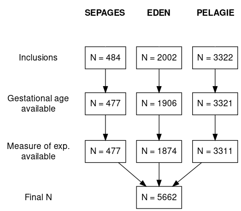

## 4.2 N births per cohort per year

|  | 2003 | 2004 | 2005 | 2006 | 2002 | 2015 | 2016 | 2017 | 2018 |
| --- | --- | --- | --- | --- | --- | --- | --- | --- | --- |
| ed_n | 13 | 444 | 289 | 214 | 0 | 0 | 0 | 0 | 0 |
| ed_p | 177 | 408 | 329 | 0 | 0 | 0 | 0 | 0 | 0 |
| pel_22 | 0 | 200 | 534 | 260 | 0 | 0 | 0 | 0 | 0 |
| pel_29 | 64 | 123 | 0 | 0 | 0 | 0 | 0 | 0 | 0 |
| pel_35 | 929 | 884 | 275 | 0 | 42 | 0 | 0 | 0 | 0 |
| sep | 0 | 0 | 0 | 0 | 0 | 128 | 218 | 127 | 4 |

## 4.3 Population description

| name | All | Eden | Pelagie | Sepages |
| --- | --- | --- | --- | --- |
| **Temperature** |  |  |  |  |
| Temperature over entire pregnancy (C) | 11.99 (2.3) | 11.53 (2.6) | 12.16 (2.01) | 12.67 (2.62) |
| **Gestation duration** |  |  |  |  |
| Gestation duration | 37.91 (1.74) | 37.69 (1.78) | 38.07 (1.72) | 37.72 (1.55) |
| **Maternal age at conception** |  |  |  |  |
| <25 years | 779 (13.8%) | 374 (20%) | 392 (11.8%) | 13 (2.7%) |
| 25 - 29 years | 2149 (38%) | 691 (36.9%) | 1347 (40.7%) | 111 (23.3%) |
| 30 - 34 years | 1913 (33.8%) | 564 (30.1%) | 1122 (33.9%) | 227 (47.6%) |
| >=35 years | 804 (14.2%) | 245 (13.1%) | 433 (13.1%) | 126 (26.4%) |
| Missing | 17 (0.3%) | 0 | 17 (0.5%) | 0 |
| **Maternal education** |  |  |  |  |
| Baccalaureat or less | 2118 (37.4%) | 861 (45.9%) | 1228 (37.1%) | 29 (6.1%) |
| Baccalaureat + 1 or 2 years | 1414 (25%) | 419 (22.4%) | 942 (28.5%) | 53 (11.1%) |
| >=Baccalaureat +3 years | 2080 (36.7%) | 563 (30%) | 1124 (33.9%) | 393 (82.4%) |
| Missing | 50 (0.9%) | 31 (1.7%) | 17 (0.5%) | 2 (0.4%) |
| **Smoking status during pregnancy** |  |  |  |  |
| None | 4155 (73.4%) | 1394 (74.4%) | 2353 (71.1%) | 408 (85.5%) |
| Active | 1422 (25.1%) | 475 (25.3%) | 924 (27.9%) | 23 (4.8%) |
| Missing | 85 (1.5%) | 5 (0.3%) | 34 (1%) | 46 (9.6%) |
| **Parity** |  |  |  |  |
| 0 | 2517 (44.5%) | 833 (44.5%) | 1468 (44.3%) | 216 (45.3%) |
| 1 | 2126 (37.5%) | 686 (36.6%) | 1227 (37.1%) | 213 (44.7%) |
| 2 | 803 (14.2%) | 254 (13.6%) | 501 (15.1%) | 48 (10.1%) |
| ≥3 | 202 (3.6%) | 98 (5.2%) | 104 (3.1%) | 0 (0%) |
| Missing | 14 (0.2%) | 3 (0.2%) | 11 (0.3%) | 0 |
| **Infant sex** |  |  |  |  |
| Boy | 2904 (51.3%) | 978 (52.2%) | 1673 (50.5%) | 253 (53%) |
| Girl | 2756 (48.7%) | 896 (47.8%) | 1637 (49.4%) | 223 (46.8%) |
| Missing | 2 (0%) | 0 | 1 (0%) | 1 (0.2%) |
| **Season of conception** |  |  |  |  |
| Winter | 1409 (24.9%) | 442 (23.6%) | 822 (24.8%) | 145 (30.4%) |
| Spring | 1289 (22.8%) | 393 (21%) | 798 (24.1%) | 98 (20.5%) |
| Summer | 1542 (27.2%) | 541 (28.9%) | 900 (27.2%) | 101 (21.2%) |
| Autumn | 1422 (25.1%) | 498 (26.6%) | 791 (23.9%) | 133 (27.9%) |
| **Year of conception** |  |  |  |  |
| 2001 | 1 (0%) | 0 (0%) | 1 (0%) | 0 (0%) |
| 2002 | 787 (13.9%) | 92 (4.9%) | 695 (21%) | 0 (0%) |
| 2003 | 1978 (34.9%) | 774 (41.3%) | 1204 (36.4%) | 0 (0%) |
| 2004 | 1715 (30.3%) | 675 (36%) | 1040 (31.4%) | 0 (0%) |
| 2005 | 704 (12.4%) | 333 (17.8%) | 371 (11.2%) | 0 (0%) |
| 2014 | 99 (1.7%) | 0 (0%) | 0 (0%) | 99 (20.8%) |
| 2015 | 187 (3.3%) | 0 (0%) | 0 (0%) | 187 (39.2%) |
| 2016 | 169 (3%) | 0 (0%) | 0 (0%) | 169 (35.4%) |
| 2017 | 22 (0.4%) | 0 (0%) | 0 (0%) | 22 (4.6%) |
| **Pre-pregnancy BMI** |  |  |  |  |
| Mean BMI in kg/m2 (SD) | 22.71 (4.27) | 23.24 (4.6) | 22.46 (4.12) | 22.37 (3.79) |
| Missing | 66 (1%) | 38 (2%) | 24 (1%) | 4 (1%) |
| **Urbanisation** |  |  |  |  |
| City-center | 948 (16.7%) | 196 (10.5%) | 576 (17.4%) | 176 (36.9%) |
| Small city-center and suburban areas | 2121 (37.5%) | 917 (48.9%) | 961 (29%) | 243 (50.9%) |
| Rural area | 2585 (45.7%) | 761 (40.6%) | 1773 (53.5%) | 51 (10.7%) |
| Missing | 8 (0.1%) | 0 | 1 (0%) | 7 (1.5%) |
| **NDVI** |  |  |  |  |
| Mean summer NDVI with 500m buffer around adress of birth | 0.49 (0.12) | 0.46 (0.1) | 0.5 (0.12) | 0.49 (0.16) |
| Missing | 8 (0%) | 0 | 1 (0%) | 7 (1%) |

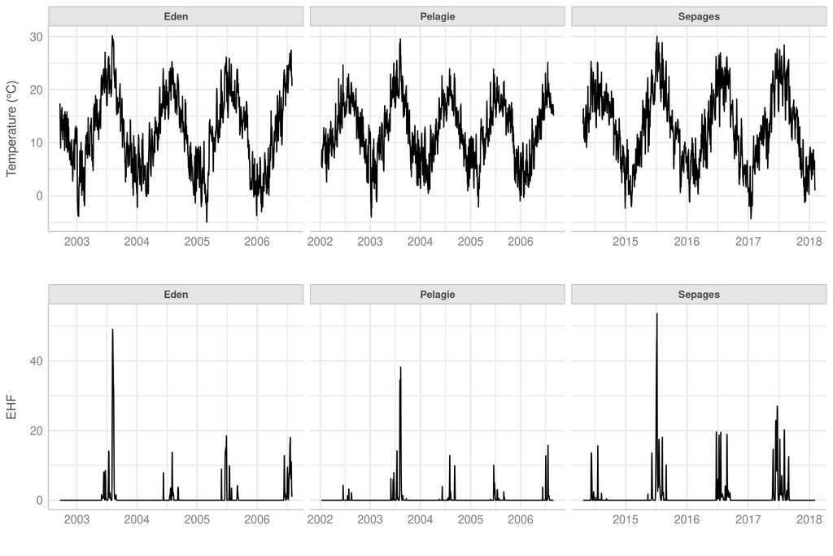

## 4.5 Percentiles

Temperature mean:

```
##       5%      95%
##  2.30000 21.82857
```

Temperature SD:

```
##       5%      95%
## 0.784978 3.784178
```

EHF:

```
##       5%      95%
## 0.000000 2.884567
```

## 4.6 Multivariate models

Models are:

| df_var | df_lag | tmean_mean | tmean_sd | ehf_fw | tmean_val | ehf_bw |
| --- | --- | --- | --- | --- | --- | --- |
| 3 | 3 | 4545.39 | 4543.248 | 4539.798 | 4546.286 | 4540.31 |
| 3 | 4 | 4548.886 | 4548.504 | 4541.458 | 4550.149 | 4541.829 |
| 3 | 5 | 4554.202 | 4550.604 | 4543.223 | 4554.095 | 4541.735 |
| 3 | 6 | 4557.471 | 4548.454 | 4545.216 | 4555.695 | 4541.527 |
| 4 | 3 | 4540.535 | 4547.508 | 4539.798 | 4549.237 | 4540.31 |
| 4 | 4 | 4545.386 | 4554.749 | 4541.458 | 4555.434 | 4541.829 |
| 4 | 5 | 4552.452 | 4558.326 | 4543.223 | 4560.692 | 4541.735 |
| 4 | 6 | 4557.162 | 4558.493 | 4545.216 | 4561.64 | 4541.527 |
| 5 | 3 | 4545.731 | 4551.28 | 4539.798 | 4555.319 | 4540.31 |
| 5 | 4 | 4552.4 | 4560.474 | 4541.458 | 4563.092 | 4541.829 |
| 5 | 5 | 4560.446 | 4565.399 | 4543.223 | 4569.882 | 4541.735 |
| 5 | 6 | 4567.369 | 4566.771 | 4545.216 | 4570.439 | 4541.527 |
| 6 | 3 | 4545.697 | 4556.651 | 4539.798 | 4552.642 | 4540.31 |
| 6 | 4 | 4552.076 | 4564.901 | 4541.458 | 4558.218 | 4541.829 |
| 6 | 5 | 4561.085 | 4570.752 | 4543.223 | 4562.49 | 4541.735 |
| 6 | 6 | 4569.759 | 4574.109 | 4545.216 | 4566.979 | 4541.527 |

### 4.6.1 Weekly mean temperature

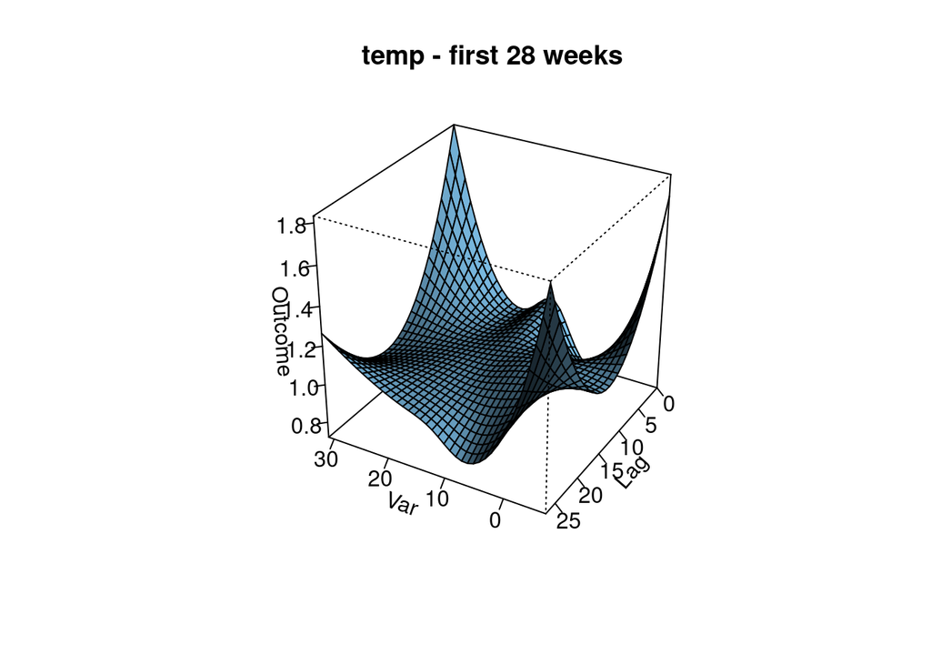

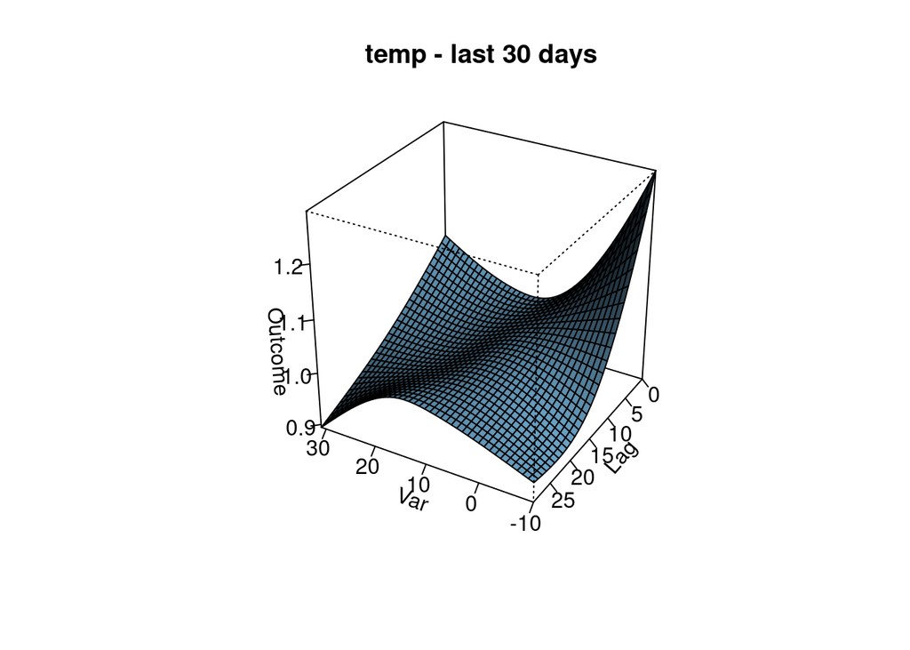

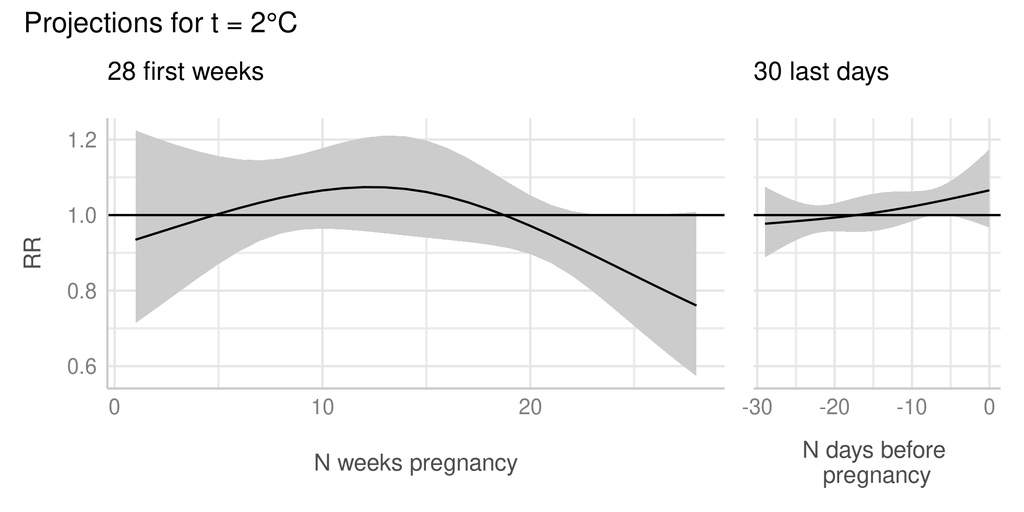

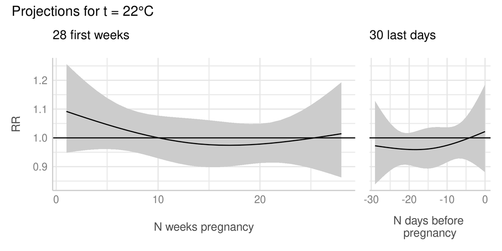

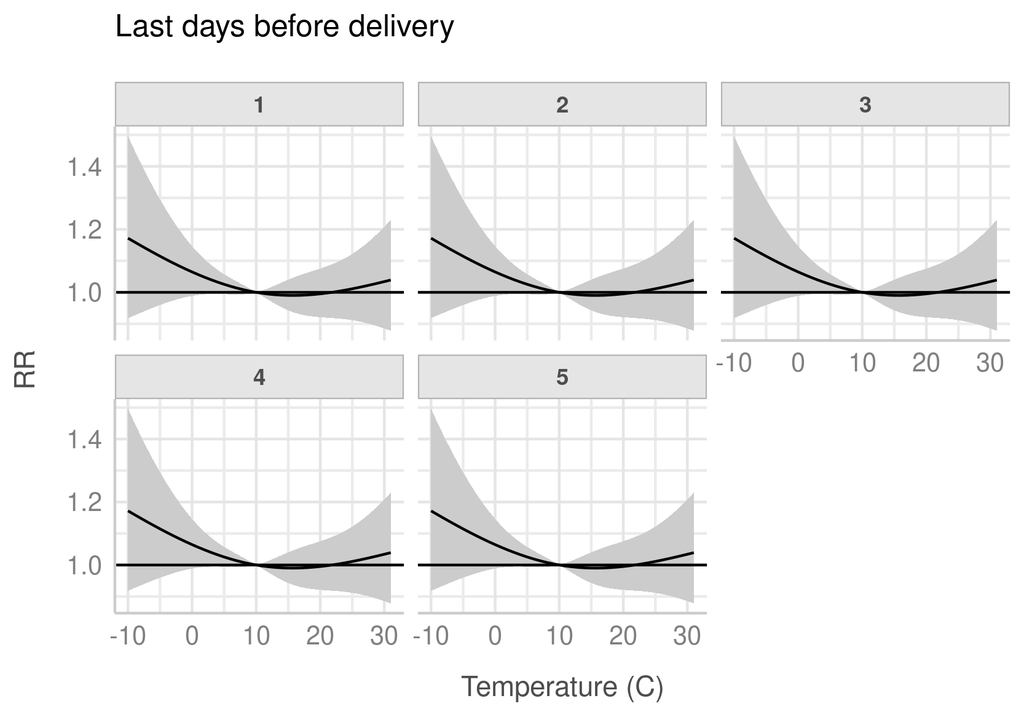

### 4.6.2 Weekly mean temperature SD

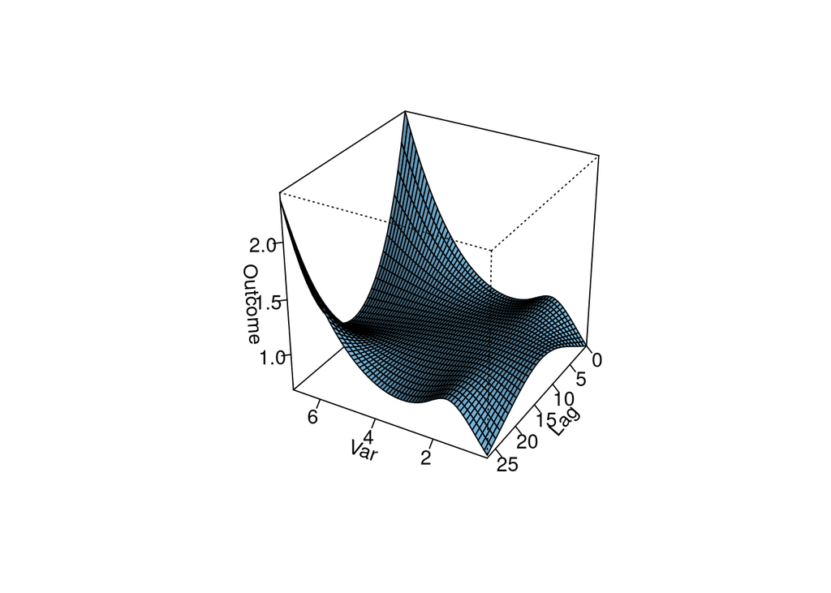

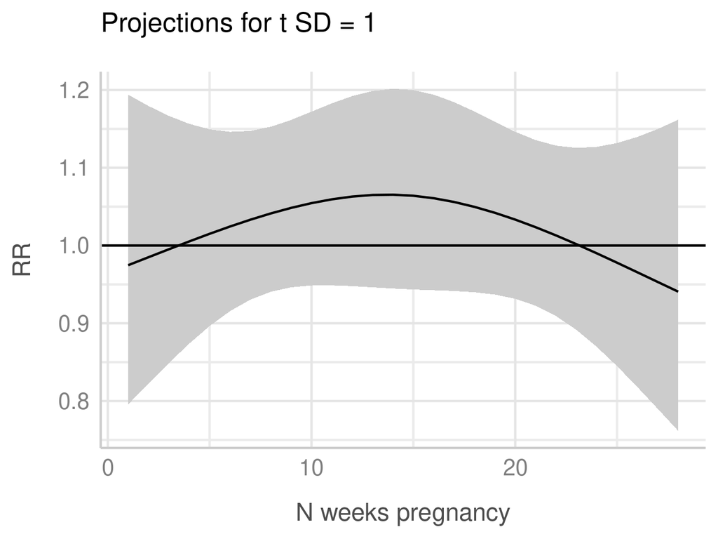

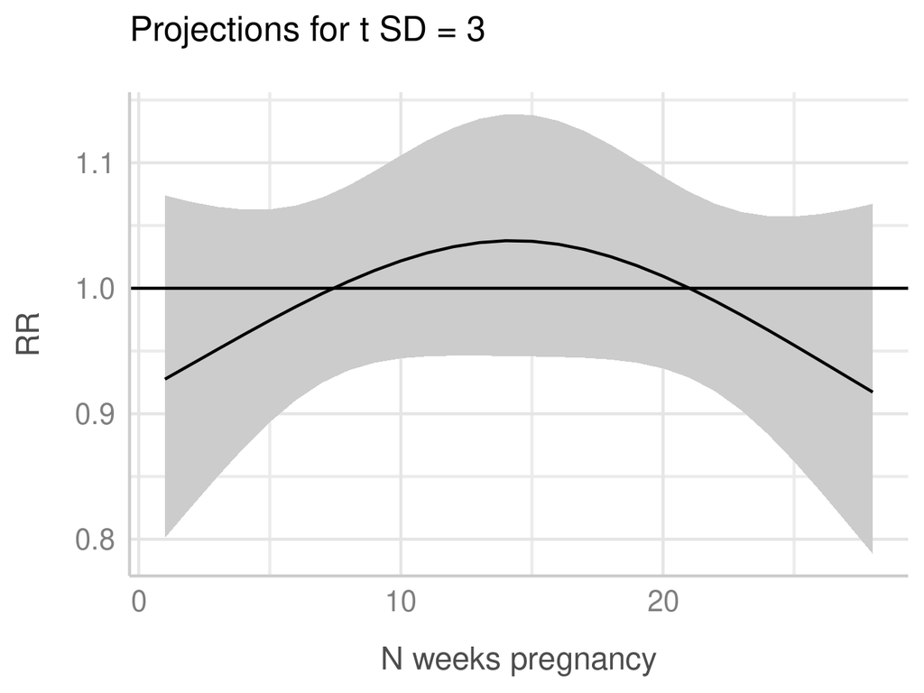

### 4.6.3 Daily EHF

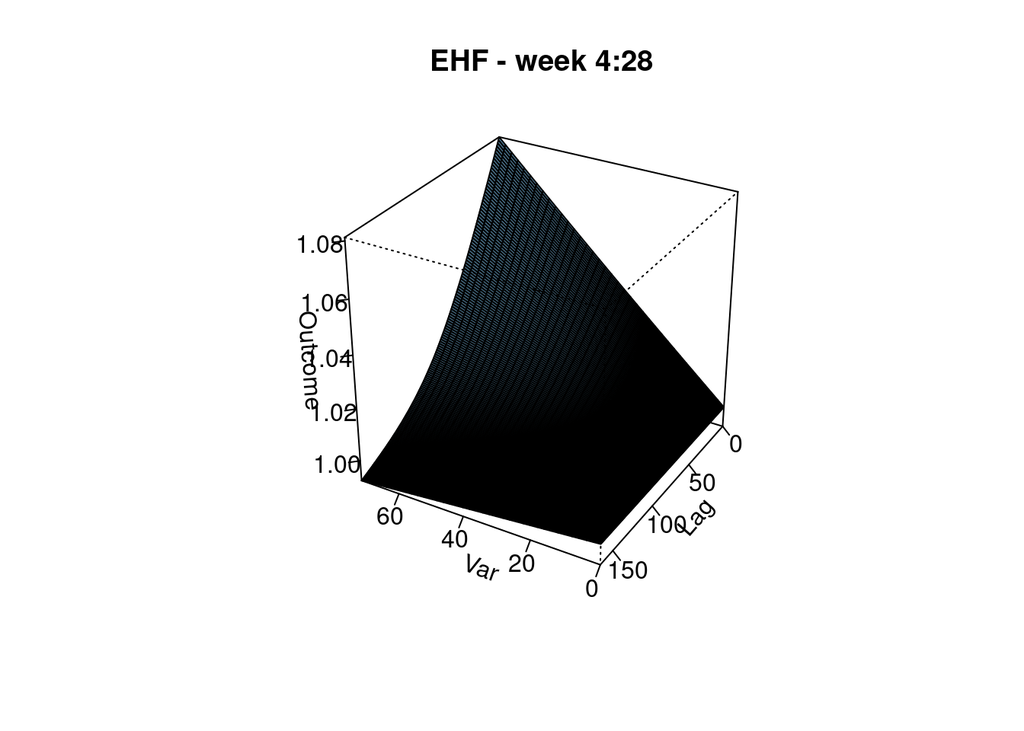

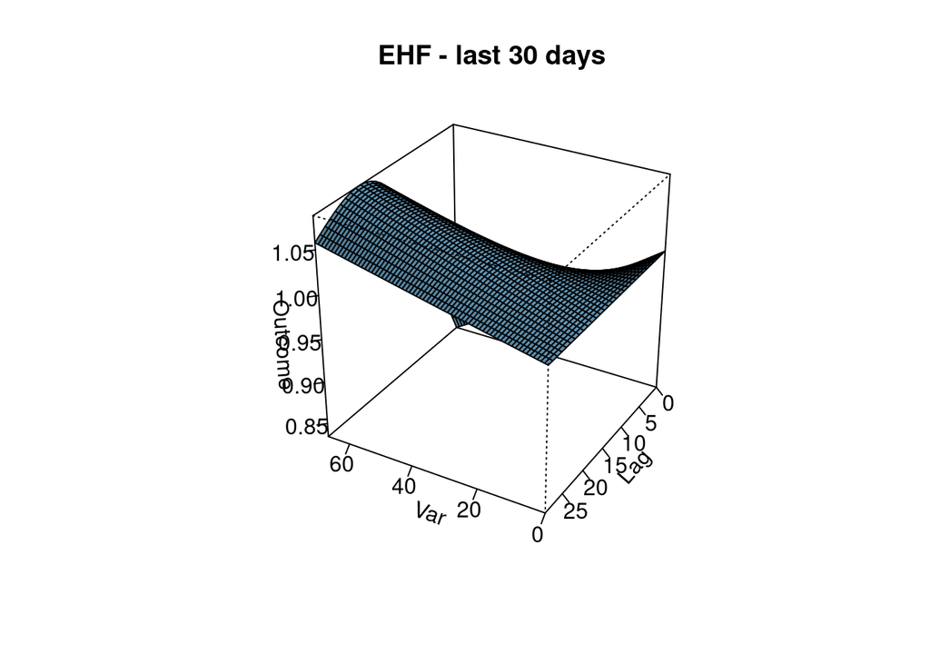

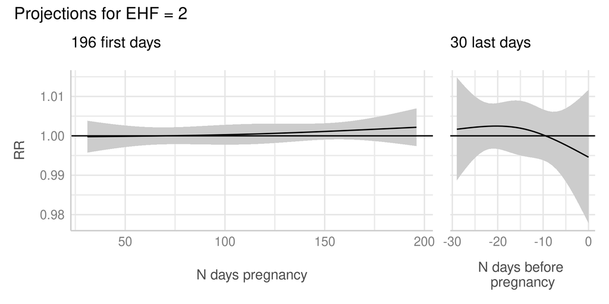

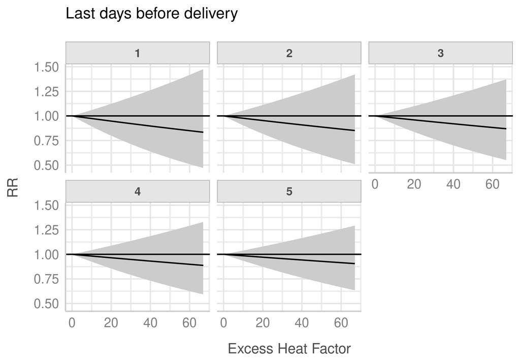

# 5 In brief

- No significant associations
- Exposure to high and low temperatures in the last days of pregnancy seam to increase the risk of PTB
- Low SD could be protective at the end of pregnancy and high SD increase the risk of PTB **BUT NEED TO CHECK BACKWARD MODEL**
- No observable effect of EHF
- Regarding proportional hazards hypothesis: only for the maternal education was the proportionality hazard asumption not met (schoenfiel p < 0.05) but results were identical with and without this variable

# 6 Sensitivity

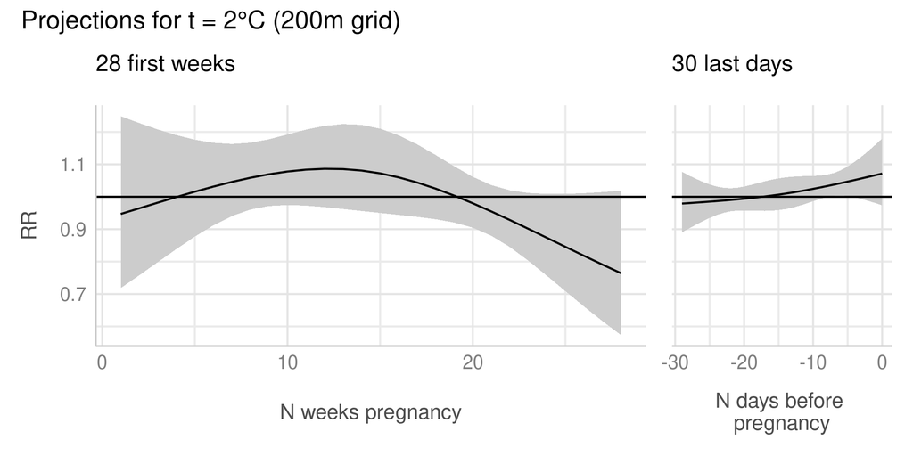

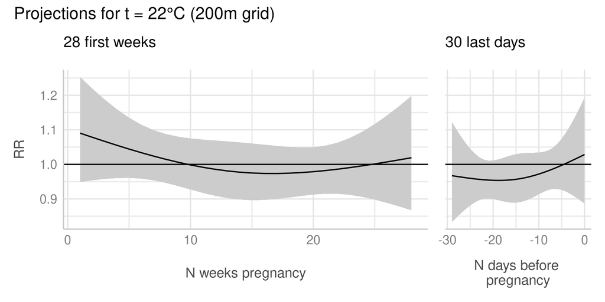

# References

Gasparrini, Antonio. 2011. “Distributed Lag Linear and Non-Linear Models in *R* : The Package **Dlnm**.” *Journal of Statistical Software* 43 (8). https://doi.org/10.18637/jss.v043.i08.

———. 2014. “Modeling Exposure-Lag-Response Associations with Distributed Lag Non-Linear Models.” *Statistics in Medicine* 33 (5): 881–99. https://doi.org/10.1002/sim.5963.

Heude, Barbara, Anne Forhan, Rémy Slama, Lorraine Douhaud, Sophie Bedel, Marie-Josèphe Saurel-Cubizolles, Régis Hankard, et al. 2016. “Cohort Profile: The EDEN Mother-Child Cohort on the Prenatal and Early Postnatal Determinants of Child Health and Development.” *International Journal of Epidemiology* 45 (2): 353–63. https://doi.org/10.1093/ije/dyv151.

Hough, Ian, Allan C. Just, Bin Zhou, Michael Dorman, Johanna Lepeule, and Itai Kloog. 2020. “A Multi-Resolution Air Temperature Model for France from MODIS and Landsat Thermal Data.” *Environmental Research* 183 (April): 109244. https://doi.org/10.1016/j.envres.2020.109244.

Lyon-Caen, Sarah, Valérie Siroux, Johanna Lepeule, Philippe Lorimier, Pierre Hainaut, Pascal Mossuz, Joane Quentin, et al. 2019. “Deciphering the Impact of Early-Life Exposures to Highly Variable Environmental Factors on Foetal and Child Health: Design of SEPAGES Couple-Child Cohort.” *International Journal of Environmental Research and Public Health* 16 (20): 3888. https://doi.org/10.3390/ijerph16203888.

Nairn, John, and Robert Fawcett. 2014. “The Excess Heat Factor: A Metric for Heatwave Intensity and Its Use in Classifying Heatwave Severity.” *International Journal of Environmental Research and Public Health* 12 (1): 227–53. https://doi.org/10.3390/ijerph120100227.

Petit, C., M. Blangiardo, S. Richardson, F. Coquet, C. Chevrier, and S. Cordier. 2012. “Association of Environmental Insecticide Exposure and Fetal Growth with a Bayesian Model Including Multiple Exposure Sources: The PELAGIE Mother-Child Cohort.” *American Journal of Epidemiology* 175 (11): 1182–90. https://doi.org/10.1093/aje/kwr422.

R Core Team. 2020. *R: A Language and Environment for Statistical Computing*. Vienna, Austria: R Foundation for Statistical Computing. https://www.R-project.org/.

Sun, Yi, Paige Sheridan, Olivier Laurent, Jia Li, David A. Sacks, Heidi Fischer, Yang Qiu, et al. 2020. “Associations Between Green Space and Preterm Birth: Windows of Susceptibility and Interaction with Air Pollution.” *Environment International* 142 (September): 105804. https://doi.org/10.1016/j.envint.2020.105804.

Wang, Qiong, Tarik Benmarhnia, Huanhuan Zhang, Luke D. Knibbs, Paige Sheridan, Changchang Li, Junzhe Bao, et al. 2018. “Identifying Windows of Susceptibility for Maternal Exposure to Ambient Air Pollution and Preterm Birth.” *Environment International* 121 (December): 317–24. https://doi.org/10.1016/j.envint.2018.09.021.

Wang, Qiong, Bing Li, Tarik Benmarhnia, Shakoor Hajat, Meng Ren, Tao Liu, Luke D. Knibbs, et al. 2020. “Independent and Combined Effects of Heatwaves and PM2.5 on Preterm Birth in Guangzhou, China: A Survival Analysis.” *Environmental Health Perspectives* 128 (1): 017006. https://doi.org/10.1289/EHP5117.